# COVID-19 Prediction using Explainable Machine Learning

## Classification

### SVM

We experimented with Support Vector Classifiers with Radial Basis function as kernel. The following diagram shows the data before over-sampling.

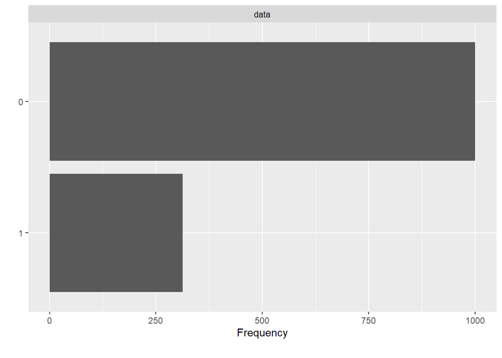

```r
load('covid_data_new_masked')
dataset <- covid_data
plot_bar(dataset$V59)
```

Before feeding data onto the classifier, we oversampled with AdaSyn method.

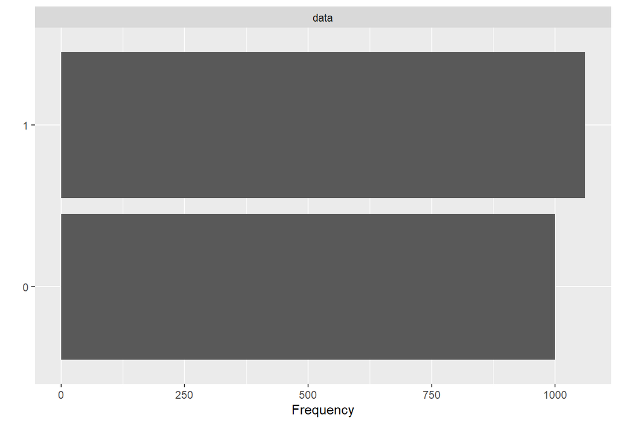

```r
#Over-sampling
df.adasyn <- oversample(dataset, method = "ADASYN", classAttr = "V59")
df.adasyn$V59 = factor(df.adasyn$V59, levels = c(0, 1))
plot_bar(df.adasyn$V59)
```

```r
#train-test split
index <- 1:nrow(df.adasyn)
testindex <- sample(index, trunc(length(index)/3))
testset <- df.adasyn[testindex,]
trainset <- df.adasyn[-testindex,]
```

```r
set.seed(825)
#Training the model to the Training set
svm_fit_ovs <- svm(V59~., kernel = 'radial',
               data = trainset, scale=TRUE, cachesize = 200,
               probability = TRUE, gamma = 0.1, cost = 1)

#Predicting the test set results
svm.pred.ovs <- predict(svm_fit_ovs, testset[,-59], probability = TRUE)
```

```r
#Evaluation
ROSE::accuracy.meas(response = testset$V59, predicted = svm.pred.ovs)
```

```
##
## Call:
## ROSE::accuracy.meas(response = testset$V59, predicted = svm.pred.ovs)
##
## Examples are labelled as positive when predicted is greater than 0.5
##
## precision: 0.542
## recall: 1.000
## F: 0.352
```

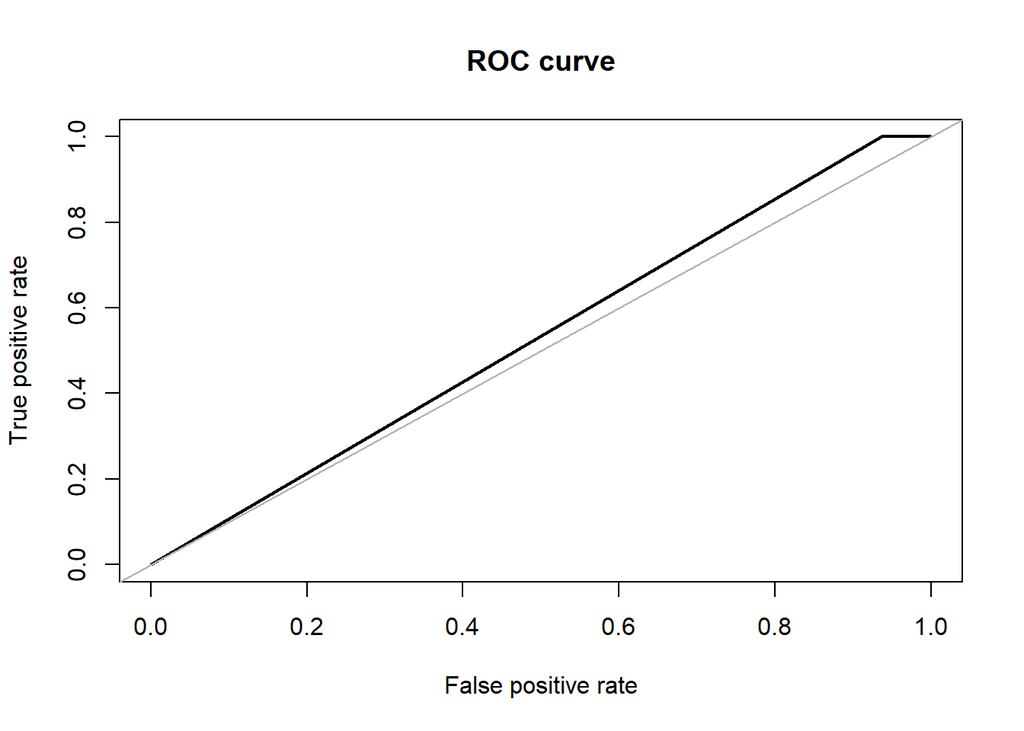

```
## Area under the curve (AUC): 0.532
```

```r
ROSE::roc.curve(testset$V59, svm.pred.ovs, plotit = T)
```

```r
caret::confusionMatrix(svm.pred.ovs, testset$V59, positive = '1')
```

```
## Confusion Matrix and Statistics
##
##           Reference
## Prediction   0   1
##          0  20   0
##          1 294 372
##
##                Accuracy : 0.5714
##                  95% CI : (0.5334, 0.6088)
##     No Information Rate : 0.5423
##     P-Value [Acc > NIR] : 0.06733
##
##                   Kappa : 0.0687
##
##  Mcnemar's Test P-Value : < 2e-16
##
##             Sensitivity : 1.00000
##             Specificity : 0.06369
##          Pos Pred Value : 0.55856
##          Neg Pred Value : 1.00000
##              Prevalence : 0.54227
##          Detection Rate : 0.54227
##    Detection Prevalence : 0.97085
##       Balanced Accuracy : 0.53185
##
##        'Positive' Class : 1
##
```

### kNN

K-Neigherst Neighbour is one of the models used for classification. kNN has been successfully used in tasks where texture-based descriptors are used [16]. In kNN classification, we expect that the classifier will examine the k nearest neighbors and return the class labels associated with the majority of k nearest neighbor. The accuracy of the model depends heavily on k, i.e. the number of nearest neighbors to consider for classification purpose. So, each neighbor adds a vote or a confidence towards the classification of a query instance. We use this model, in hope that the features extracted above captures the specific discriminatory properties of the lung area and on similar note the nearest neighbors will capture the same properties.

We initially split the data by a proportion of 30:70 distributed among both the classes for test and training purpose.

```r
dim(glass.df)
```

```
## [1] 1313   59
```

```r
# all the independent variables are numbers
# we will convert the type variable which is the response variable as factor
glass.df$V59<- as.factor(glass.df$V59) # 7 labels

# training and test data 70:30
set.seed(123)
ind = sample(2, nrow(glass.df), replace = TRUE, prob=c(0.7,0.3))
train.df = glass.df[ind == 1,]
test.df = glass.df[ind == 2,]
```

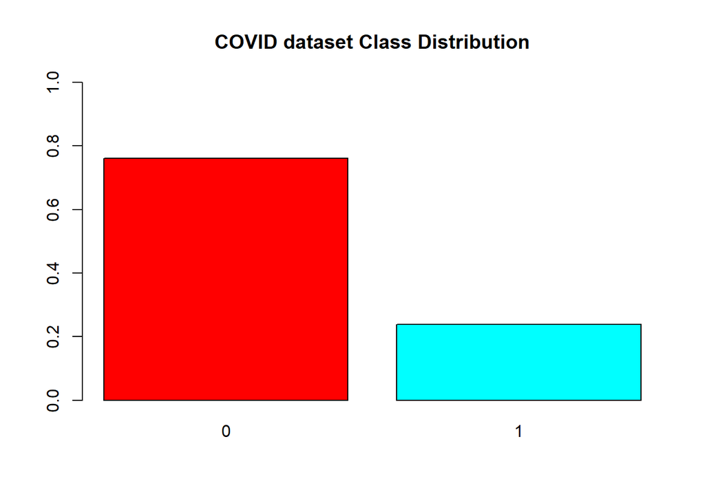

```r
#Visualizing distribution of each class
barplot(prop.table(table(glass.df$V59)),
        col = rainbow(2),
        ylim = c(0,1),
        main = "COVID dataset Class Distribution")
```

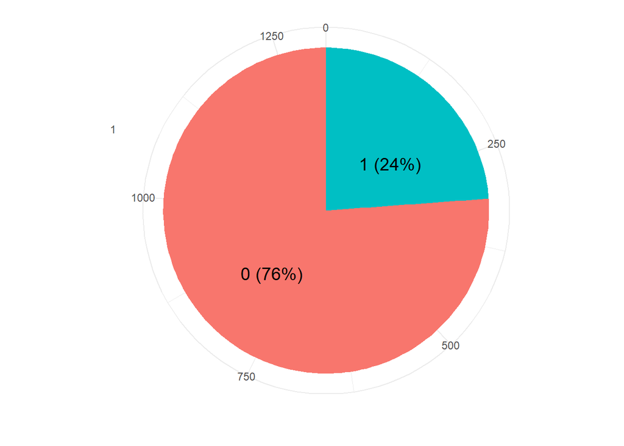

```r
resTable <- glass.df %>% tabyl(V59)
resTable$labels <- paste0(resTable$V59, " (", scales::percent(resTable$percent), ") ")

resTable %>%ggplot(aes(x=factor(1),y=n, fill=V59))+
  geom_bar(width = 1, stat='identity')+
  coord_polar("y")+
  theme_minimal()+
  geom_text(aes(y = c(800,200),
            label = labels), size=5)+
  theme(legend.position = 'none')+
  labs(y='', x='')
```

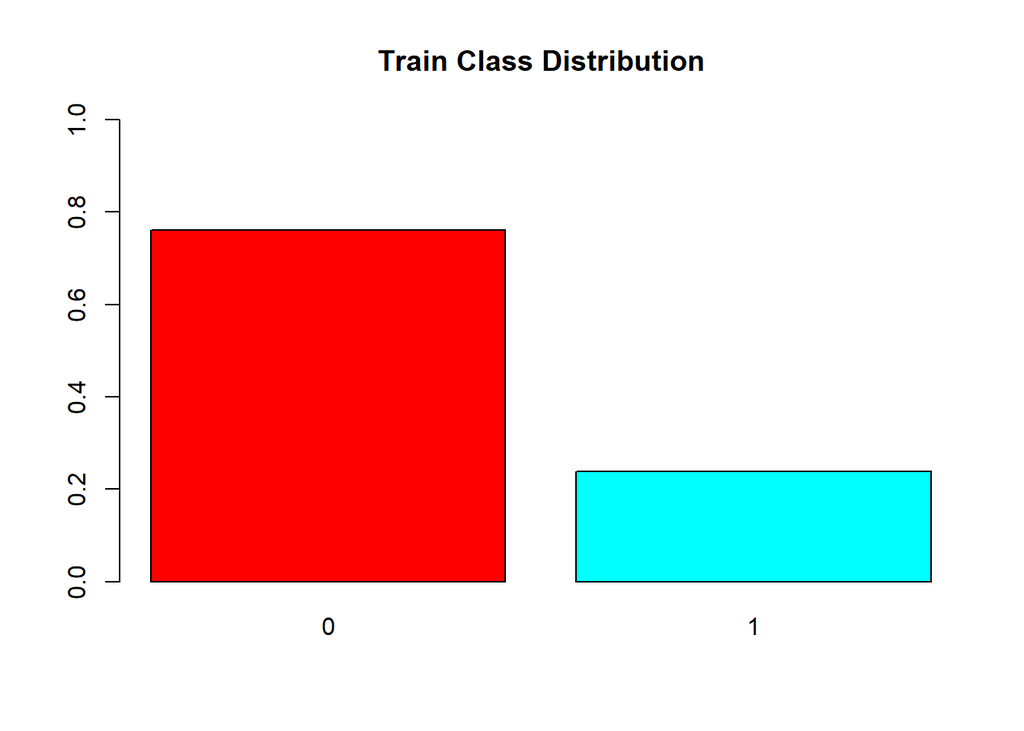

```r
barplot(prop.table(table(train.df$V59)),
        col = rainbow(2),
        ylim = c(0,1),
        main = "Train Class Distribution")
```

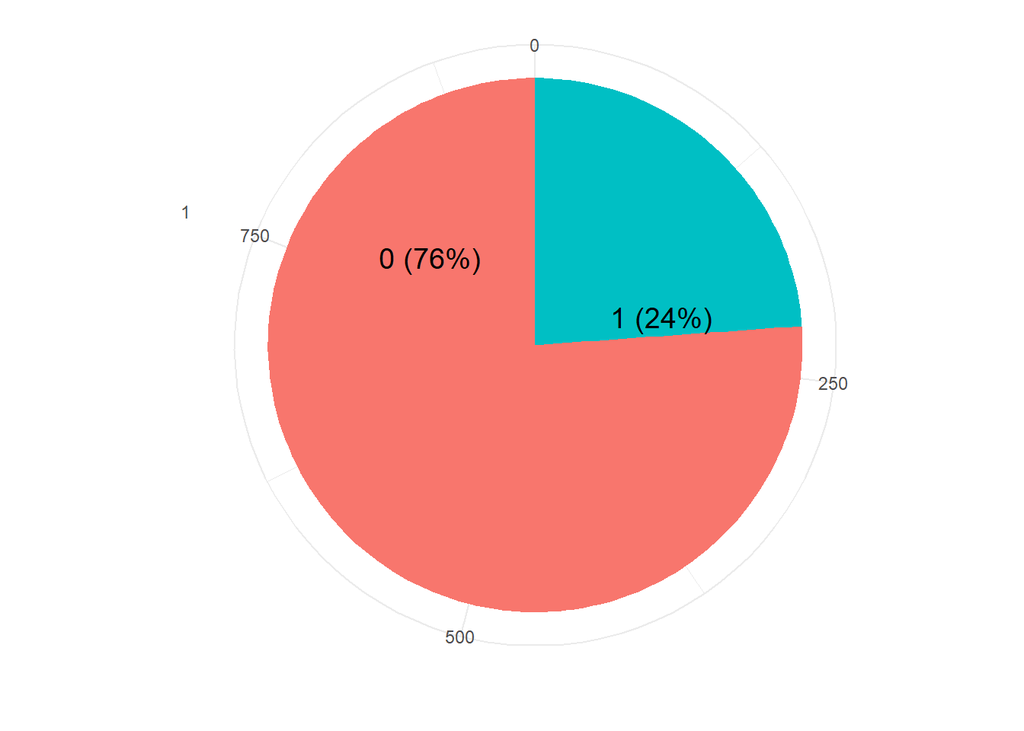

```r
resTable <- train.df %>% tabyl(V59)
resTable$labels <- paste0(resTable$V59, " (", scales::percent(resTable$percent), ") ")

resTable %>%ggplot(aes(x=factor(1),y=n, fill=V59))+
  geom_bar(width = 1, stat='identity')+
  coord_polar("y")+
  theme_minimal()+
  geom_text(aes(y = c(800,200),
            label = labels), size=5)+
  theme(legend.position = 'none')+
  labs(y='', x='')
```

```r
# Create data for the graph.
```

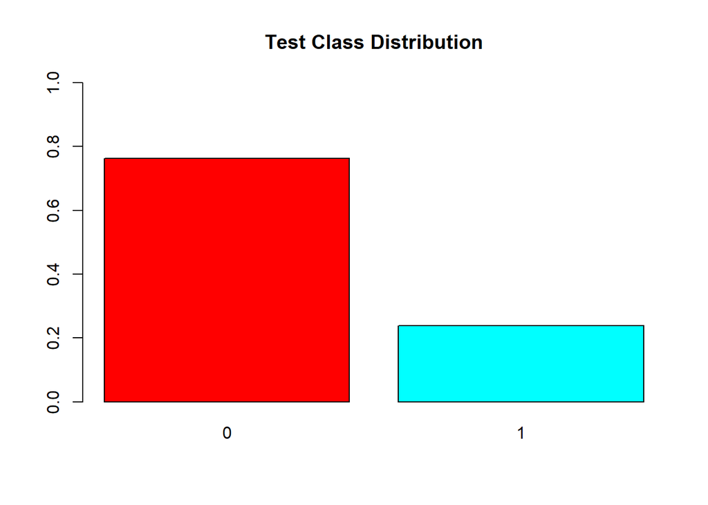

```r
barplot(prop.table(table(test.df$V59)),
        col = rainbow(2),
        ylim = c(0,1),
        main = "Test Class Distribution")
```

For training, to tackle the class imbalance problem we used 10 cross validation with 3 repeats. That is data will be split entirely 3 times, and for each of the 3 times, 10-fold cross validation is done for validation.

```r
trctrl <- trainControl(method = "repeatedcv", number = 10, repeats = 3)
```

For evaluation of K, we decide at train time, the number that gives the highest accuracy. In our case, k=9 gave us the best accuracy.

```r
knn_fit <- train(V59 ~., data = train.df, method = "knn",
                 trControl=trctrl,
                 preProcess = c("center", "scale"),
                 tuneLength = 15)
```

```r
summary(knn_fit)
```

```
##             Length Class      Mode
## learn        2     -none-     list
## k            1     -none-     numeric
## theDots      0     -none-     list
## xNames      58     -none-     character
## problemType  1     -none-     character
## tuneValue    1     data.frame list
## obsLevels    2     -none-     character
## param        0     -none-     list
```

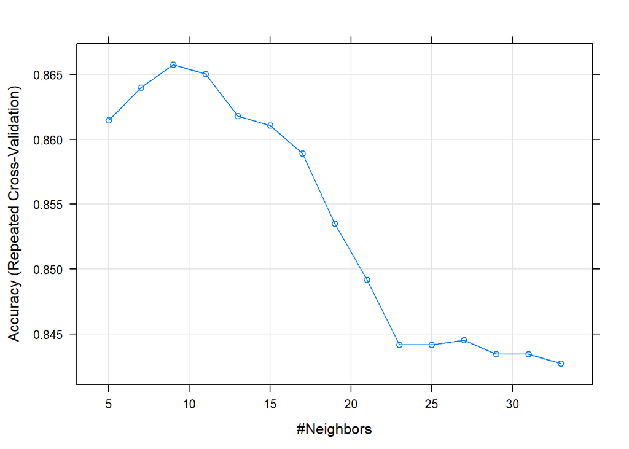

```r
plot(knn_fit)
```

The pipeline of KNN model we use, additionally centers and scales the data. The unseen instances are also subject to the same fit.

We also use a setting where the response is not a discrete positive or negative output but, gives the prediction confidence(probability) of the classifier for both of the classes.

**Results:** We test the model with the test data that was initially split out from the overall dataset

```r
test_pred <- predict(knn_fit, newdata = test.df)
summary(test_pred)
```

```
##   0   1
## 334  53
```

```r
confusionMatrix(test_pred, test.df$V59)
```

```
## Confusion Matrix and Statistics
##
##           Reference
## Prediction   0   1
##          0 286  48
##          1   9  44
##
##                Accuracy : 0.8527
##                  95% CI : (0.8134, 0.8865)
##     No Information Rate : 0.7623
##     P-Value [Acc > NIR] : 7.525e-06
##
##                   Kappa : 0.5242
##
##  Mcnemar's Test P-Value : 4.823e-07
##
##             Sensitivity : 0.9695
##             Specificity : 0.4783
##          Pos Pred Value : 0.8563
##          Neg Pred Value : 0.8302
##              Prevalence : 0.7623
##          Detection Rate : 0.7390
##    Detection Prevalence : 0.8630
##       Balanced Accuracy : 0.7239
##
##        'Positive' Class : 0
##
```

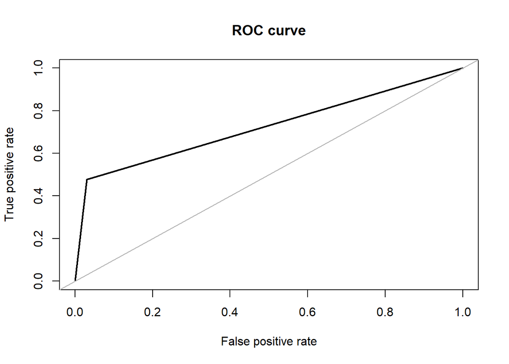

```
## Area under the curve (AUC): 0.724
```

```r
roc.curve(test.df$V59, test_pred, plotit = T)
```

### Tree Classifiers

#### Random Forest

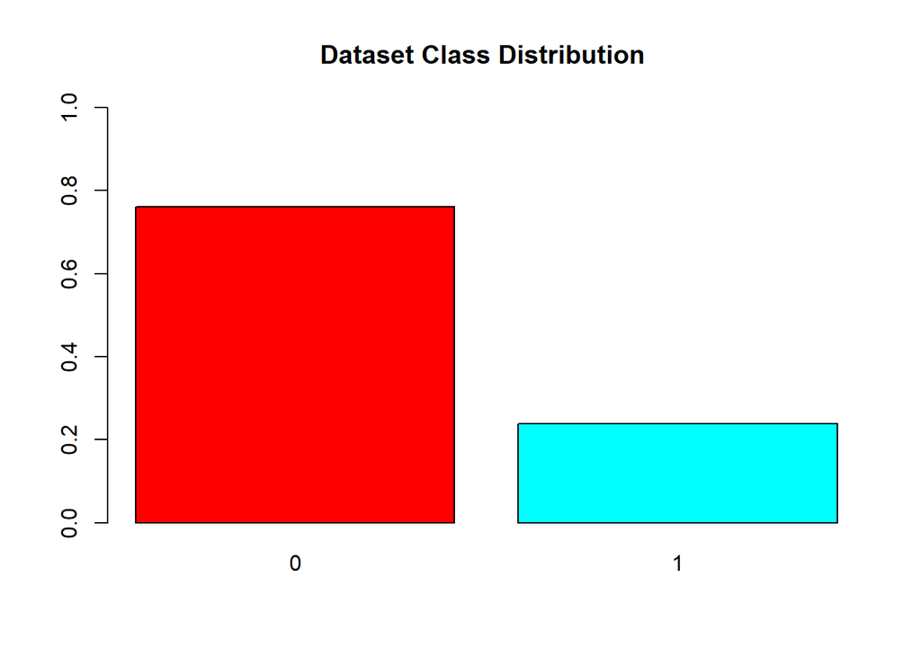

```r
#Visualizing distribution of each class
barplot(prop.table(table(covid_data$V59)),
        col = rainbow(2),
        ylim = c(0,1),
        main = "Dataset Class Distribution ")
```

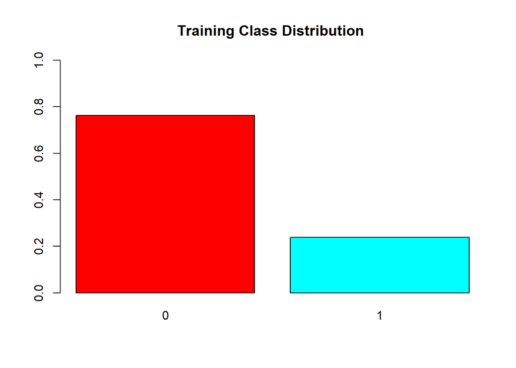

```r
barplot(prop.table(table(train$V59)),
        col = rainbow(2),
        ylim = c(0,1),
        main = "Training Class Distribution ")
```

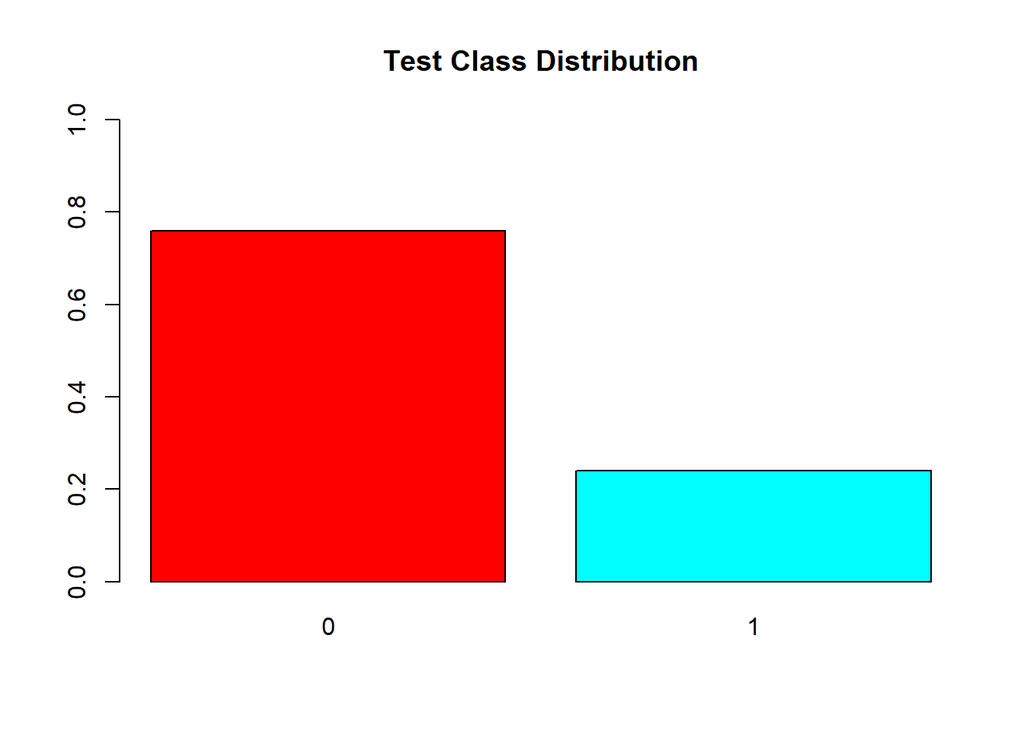

```r
barplot(prop.table(table(test$V59)),
        col = rainbow(2),
        ylim = c(0,1),
        main = "Test Class Distribution")
```

```r
#Over Sampling
over_train = ovun.sample(V59~., data = train, method = "over")$data
table(over_train$V59)
```

```
##
##   0   1
## 750 755
```

```r
over_test = ovun.sample(V59~., data = test, method = "over")$data
table(over_test$V59)
```

```
##
##   0   1
## 250 246
```

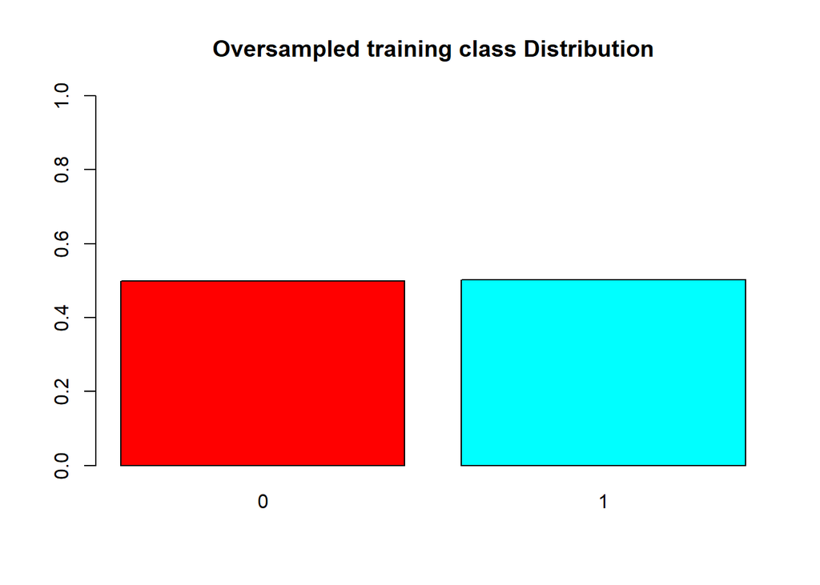

```r
barplot(prop.table(table(over_train$V59)),
        col = rainbow(2),
        ylim = c(0,1),
        main = "Oversampled training class Distribution")
```

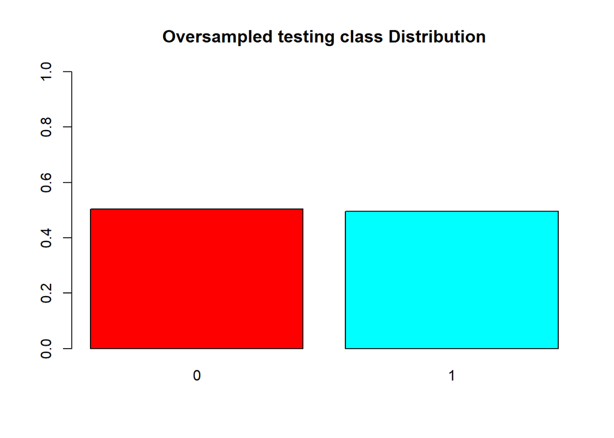

```r
barplot(prop.table(table(over_test$V59)),
        col = rainbow(2),
        ylim = c(0,1),
        main = "Oversampled testing class Distribution")
```

```r
#Random Forest
rftrain <- randomForest(V59~.,data = train)


rftrain.pred <- predict(rftrain, test)
```

[output not shown]

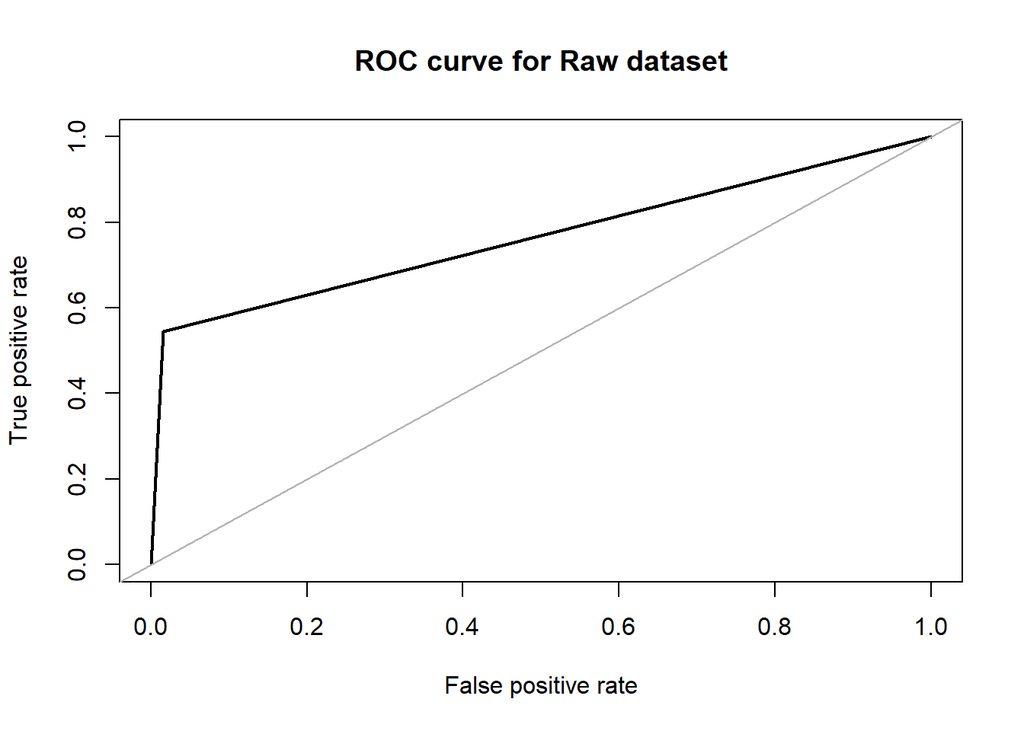

```
## Area under the curve (AUC): 0.764
```

```r
roc.curve(test$V59, rftrain.pred, plotit = T, main="ROC curve for Raw dataset")
```

```r
rftrain_over <- randomForest(V59~.,data = over_train)
rftrain_over.pred <- predict(rftrain_over, over_test)
```

```r
#Evaluation with test
confusionMatrix(predict(rftrain_over, over_test), over_test$V59, positive = '1', mode = "everything")
```

```
## Confusion Matrix and Statistics
##
##           Reference
## Prediction   0   1
##          0 242 116
##          1   8 130
##
##                Accuracy : 0.75
##                  95% CI : (0.7095, 0.7875)
##     No Information Rate : 0.504
##     P-Value [Acc > NIR] : < 2.2e-16
##
##                   Kappa : 0.4982
##
##  Mcnemar's Test P-Value : < 2.2e-16
##
##             Sensitivity : 0.5285
##             Specificity : 0.9680
##          Pos Pred Value : 0.9420
##          Neg Pred Value : 0.6760
##               Precision : 0.9420
##                  Recall : 0.5285
##                      F1 : 0.6771
##              Prevalence : 0.4960
##          Detection Rate : 0.2621
##    Detection Prevalence : 0.2782
##       Balanced Accuracy : 0.7482
##
##        'Positive' Class : 1
##
```

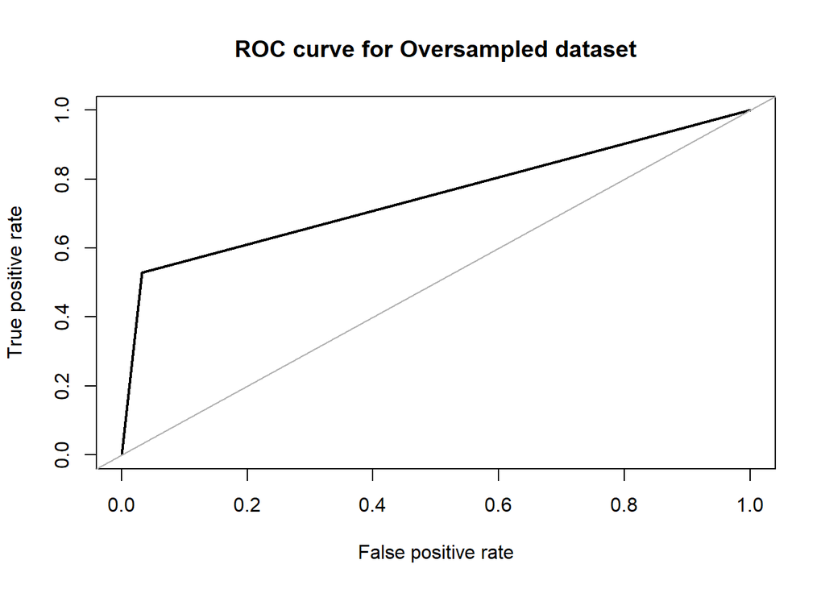

```
## Area under the curve (AUC): 0.748
```

```r
roc.curve(over_test$V59, rftrain_over.pred, plotit = T, main ="ROC curve for Oversampled dataset" )
```

#### Decision Trees

For decision trees, we used the R library ‘rpart’ which is generally used to learn classification or regression trees. We ran this algorithm in its default setting (minsplit = 20 and minbucket = round(minsplit/3)) where minsplit is the minimum number of observations that must exist in a node for a split to occur and min bucket is the minimum number of observations in any leaf node. The accuracy that we obtained on the original dataset was 87.23% with an F1 score of 0.6719. The area under the ROC curve in this case is 0.760. In the over-sampled dataset, the accuracy dropped to 70.36% with 0.6667 as F1 score. The area under the ROC curve also dropped to 0.703.

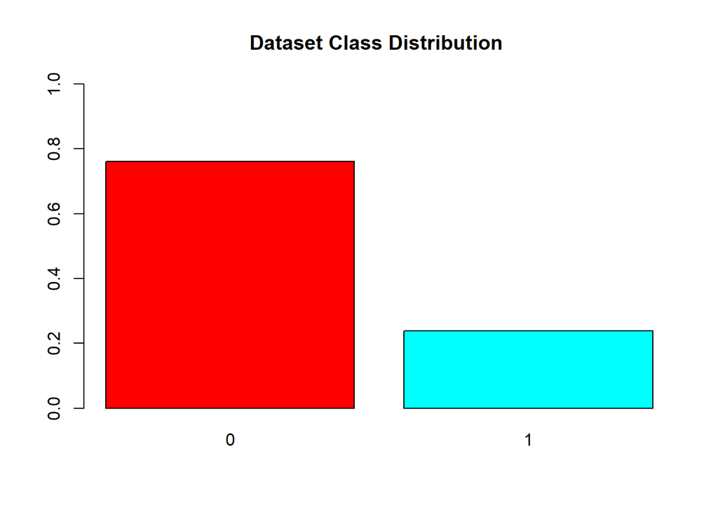

```r
load("covid_data_new_masked")
data = covid_data

#Setting V59 as factor variable as that is the target
data$V59 <- as.factor(data$V59)
#summary(data)

#Split Dataset to train and test
set.seed(123) # Set Seed so that same sample can be reproduced in future also
# Now Selecting 75% of data as sample from total 'n' rows of the data
sample <- sample.int(n = nrow(data), size = floor(.75*nrow(data)), replace = F)
train <- data[sample, ]
test  <- data[-sample, ]

#Visualizing distribution of each class
barplot(prop.table(table(covid_data$V59)),
        col = rainbow(2),
        ylim = c(0,1),
        main = "Dataset Class Distribution ")
```

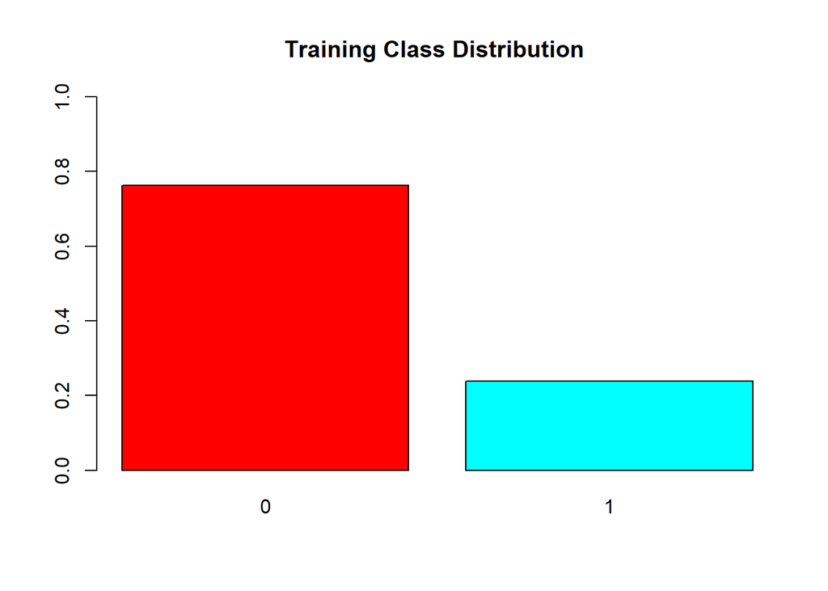

```r
barplot(prop.table(table(train$V59)),
        col = rainbow(2),
        ylim = c(0,1),
        main = "Training Class Distribution ")
```

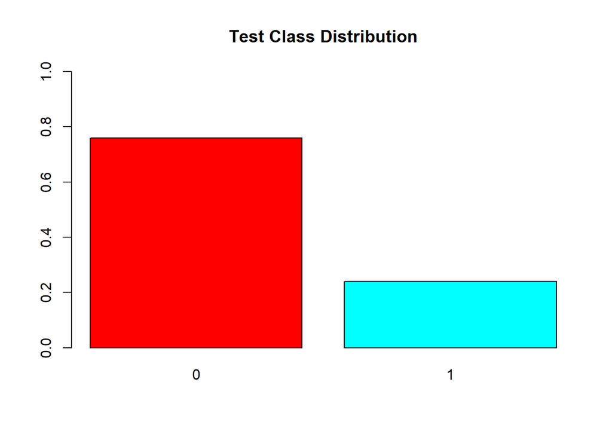

```r
barplot(prop.table(table(test$V59)),
        col = rainbow(2),
        ylim = c(0,1),
        main = "Test Class Distribution")
```

```r
#Over Sampling
over_train = ovun.sample(V59~., data = train, method = "over")$data
table(over_train$V59)
```

```
##
##   0   1
## 750 755
```

```r
over_test = ovun.sample(V59~., data = test, method = "over")$data
table(over_test$V59)
```

```
##
##   0   1
## 250 246
```

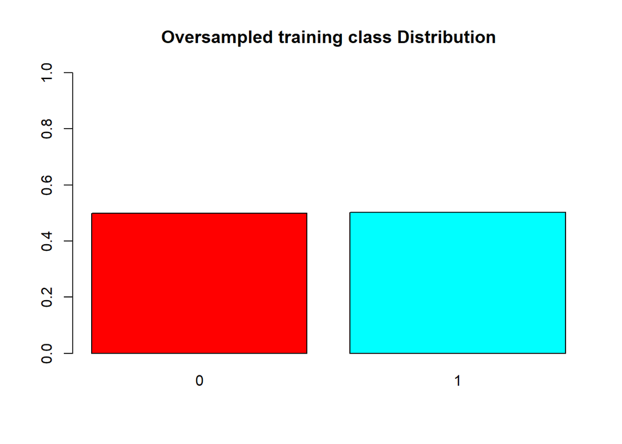

```r
barplot(prop.table(table(over_train$V59)),
        col = rainbow(2),
        ylim = c(0,1),
        main = "Oversampled training class Distribution")
```

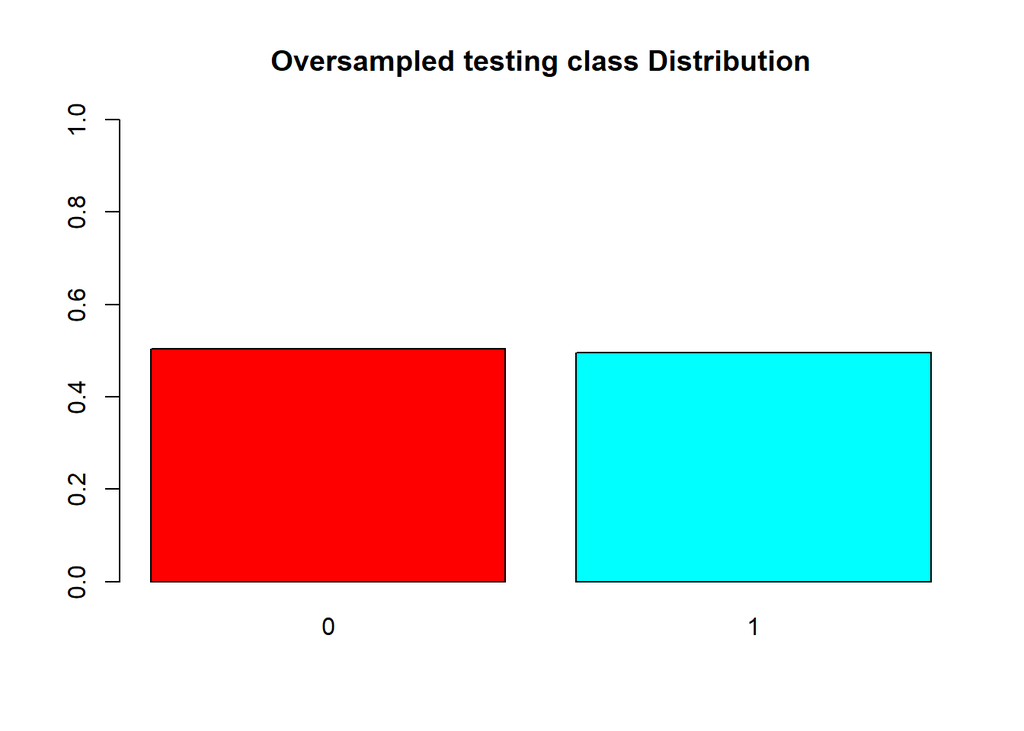

```r
barplot(prop.table(table(over_test$V59)),
        col = rainbow(2),
        ylim = c(0,1),
        main = "Oversampled testing class Distribution")
```

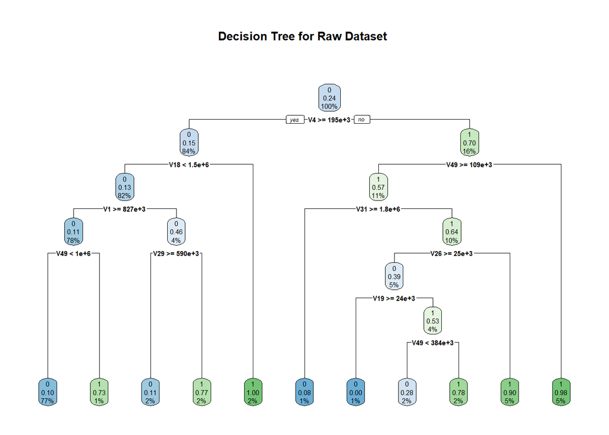

```r
#Decision Tree
dttrain <- rpart(V59~.,data = train, method = "class")


dttrain_over <- rpart(V59~.,data = over_train, method = "class")


rpart.plot(dttrain, main = "Decision Tree for Raw Dataset " )
```

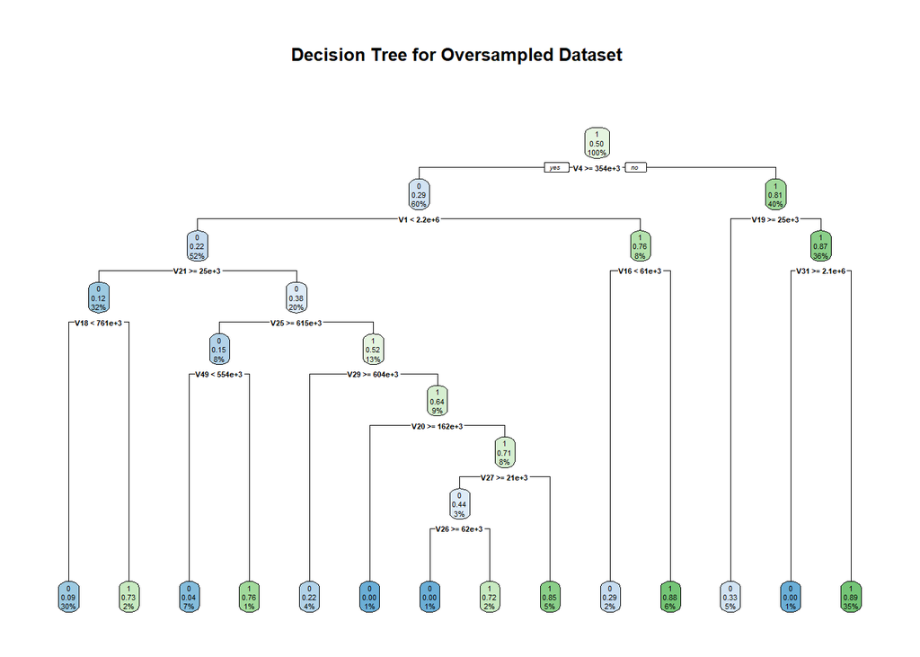

```r
rpart.plot(dttrain_over, main = "Decision Tree for Oversampled Dataset ")
```

```r
#save(dttrain, file = "DT_model")
#save(dttrain_over, file = "DT_model_over")

confusionMatrix(predict(object=dttrain,test,type="class"), test$V59, positive = '1', mode = "everything")
```

```
## Confusion Matrix and Statistics
##
##           Reference
## Prediction   0   1
##          0 244  36
##          1   6  43
##
##                Accuracy : 0.8723
##                  95% CI : (0.8314, 0.9064)
##     No Information Rate : 0.7599
##     P-Value [Acc > NIR] : 2.509e-07
##
##                   Kappa : 0.598
##
##  Mcnemar's Test P-Value : 7.648e-06
##
##             Sensitivity : 0.5443
##             Specificity : 0.9760
##          Pos Pred Value : 0.8776
##          Neg Pred Value : 0.8714
##               Precision : 0.8776
##                  Recall : 0.5443
##                      F1 : 0.6719
##              Prevalence : 0.2401
##          Detection Rate : 0.1307
##    Detection Prevalence : 0.1489
##       Balanced Accuracy : 0.7602
##
##        'Positive' Class : 1
##
```

```r
confusionMatrix(predict(object=dttrain_over,over_test,type="class"), over_test$V59, positive = '1', mode = "everything")
```

```
## Confusion Matrix and Statistics
##
##           Reference
## Prediction   0   1
##          0 202  99
##          1  48 147
##
##                Accuracy : 0.7036
##                  95% CI : (0.6613, 0.7435)
##     No Information Rate : 0.504
##     P-Value [Acc > NIR] : < 2.2e-16
##
##                   Kappa : 0.4062
##
##  Mcnemar's Test P-Value : 3.725e-05
##
##             Sensitivity : 0.5976
##             Specificity : 0.8080
##          Pos Pred Value : 0.7538
##          Neg Pred Value : 0.6711
##               Precision : 0.7538
##                  Recall : 0.5976
##                      F1 : 0.6667
##              Prevalence : 0.4960
##          Detection Rate : 0.2964
##    Detection Prevalence : 0.3931
##       Balanced Accuracy : 0.7028
##
##        'Positive' Class : 1
##
```

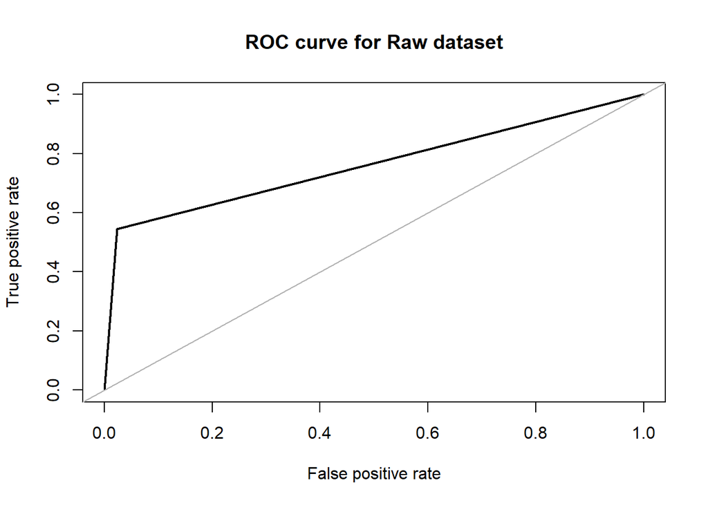

```
## Area under the curve (AUC): 0.760
```

```r
#ROC Curves
dttrain.pred <- predict(dttrain, test, type = "class")
roc.curve(test$V59, dttrain.pred, plotit = T , main ="ROC curve for Raw dataset")
```

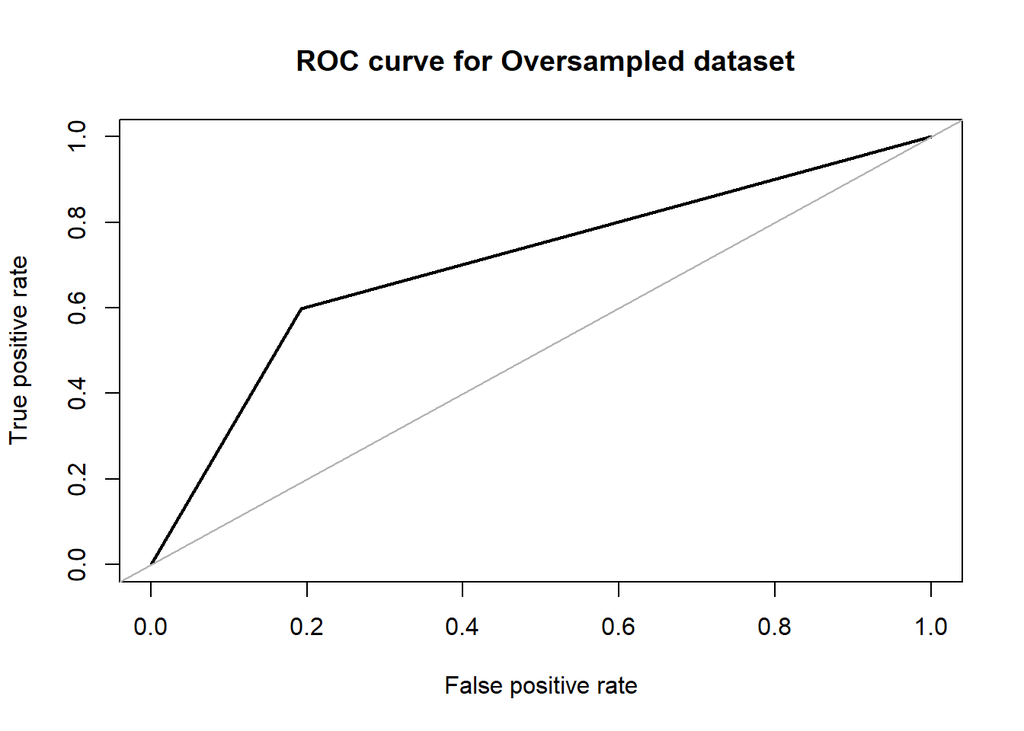

```
## Area under the curve (AUC): 0.703
```

```r
dttrain_over.pred <- predict(dttrain_over, over_test, type = "class")
roc.curve(over_test$V59, dttrain_over.pred, plotit = T ,main =" ROC curve for Oversampled dataset")
```

### Logistic Regression

> If linear regression serves to predict continuous Y variables, logistic regression is used for binary classification.

Logistic Regression is one of the basic algorithms used for binary classification.The regression model is used to function with the lbp features that was extracted from the X-ray images. The implementation was done through the ‘caret’ package that is available in R.This package has the flexibility to be applied in a regression problem extensively. For classification and regression with no tuning parameters. We achieved an accuracy of about 90.34% with an F1 score of 0.6792 in our dataset. The area under the ROC curve in this case was 0.794.

```r
load("covid_data_benchmark")
glass.df = covid_data
```

Ideally, the proportion of events and non-events in the Y variable should approximately be the same. So, lets first check the proportion of classes

```r
# all the independent variables are numbers
# we will convert the type variable which is the response variable as factor

glass.df$V59<- as.factor(glass.df$V59) # 7 labels
table(glass.df$V59)
#   0    1
# 1000  197
```

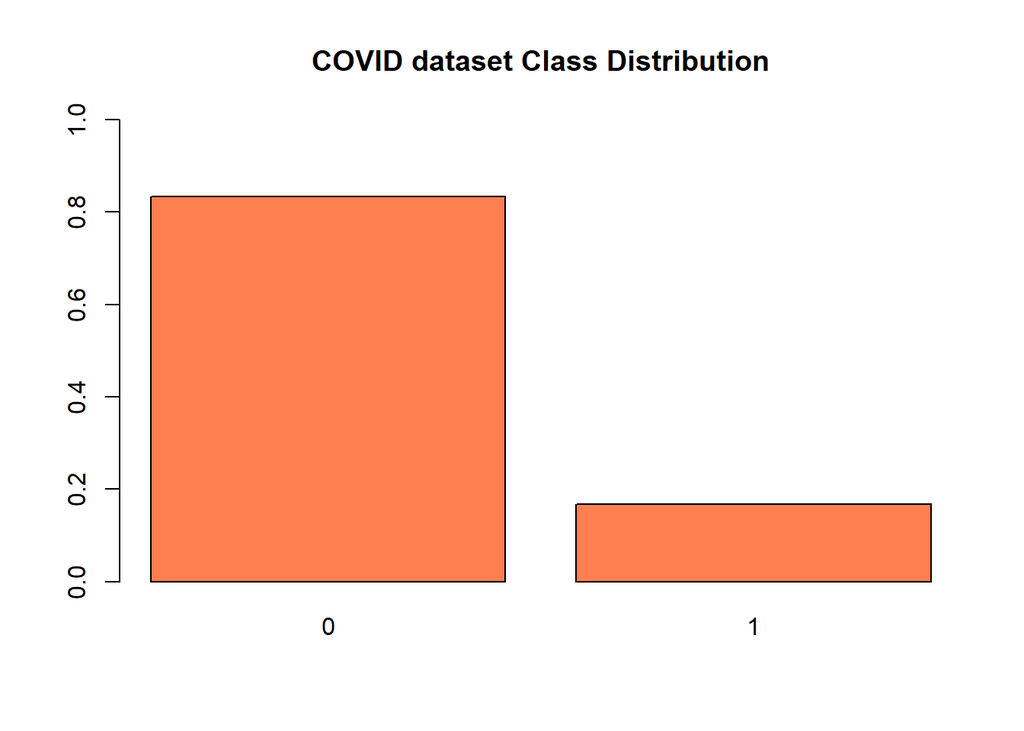

```r
#Visualizing distribution of each class
barplot(prop.table(table(glass.df$V59)),
        col = "coral",
        ylim = c(0,1),
        main = "COVID dataset Class Distribution")
```

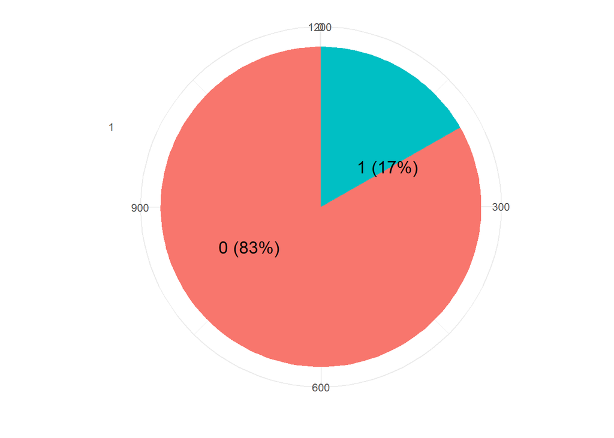

```r
resTable <- glass.df %>% tabyl(V59)
resTable$labels <- paste0(resTable$V59, " (", scales::percent(resTable$percent), ") ")

resTable %>%ggplot(aes(x=factor(1),y=n, fill=V59))+
  geom_bar(width = 1, stat='identity')+
  coord_polar("y")+
  theme_minimal()+
  geom_text(aes(y = c(800,200),
            label = labels), size=5)+
  theme(legend.position = 'none')+
  labs(y='', x='')
```

```r
# training and test data 70:30
set.seed(123)
ind = sample(2, nrow(glass.df), replace = TRUE, prob=c(0.7,0.3))
train.df = glass.df[ind == 1,]
test.df = glass.df[ind == 2,]
dim(train.df)
dim(test.df)

table(train.df$V59)

table(test.df$V59)
```

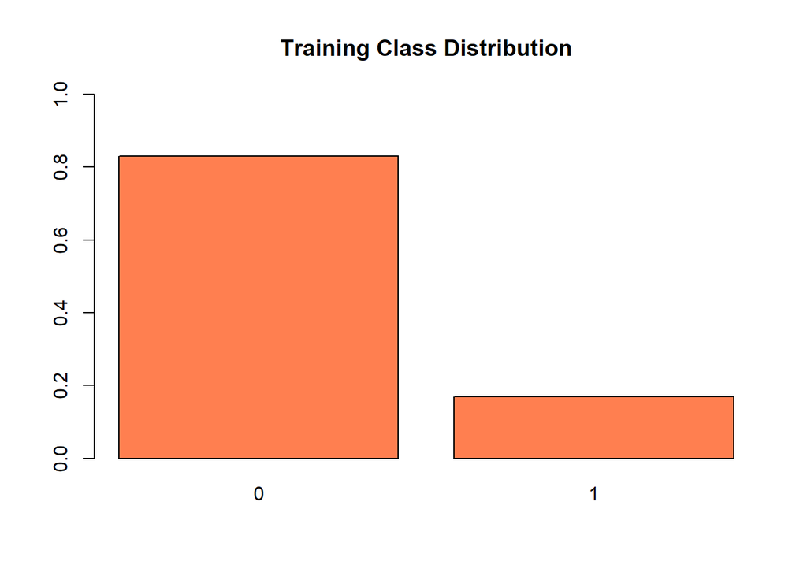

```r
barplot(prop.table(table(train.df$V59)),
        col = "coral",
        ylim = c(0,1),
        main = "Training Class Distribution")
```

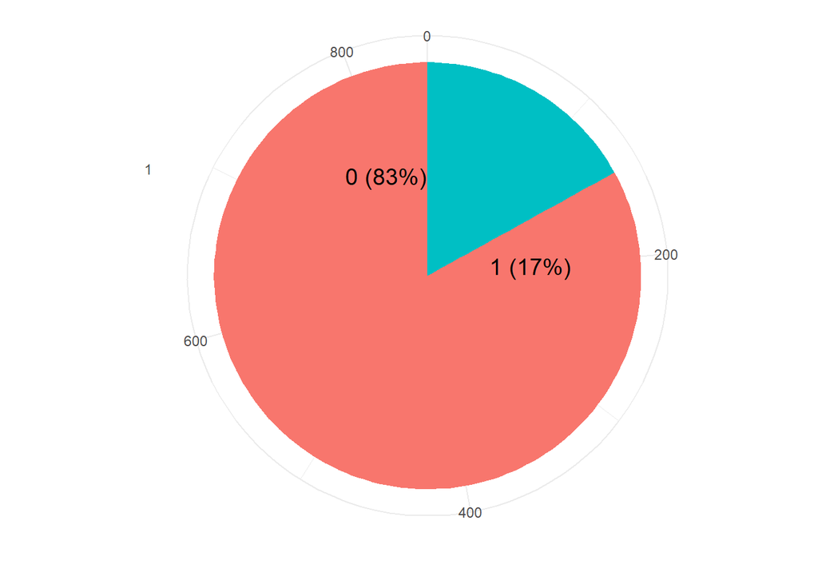

```r
resTable <- train.df %>% tabyl(V59)
resTable$labels <- paste0(resTable$V59, " (", scales::percent(resTable$percent), ") ")

resTable %>%ggplot(aes(x=factor(1),y=n, fill=V59))+
  geom_bar(width = 1, stat='identity')+
  coord_polar("y")+
  theme_minimal()+
  geom_text(aes(y = c(800,200),
            label = labels), size=5)+
  theme(legend.position = 'none')+
  labs(y='', x='')
```

```r
# Create data for the graph.
```

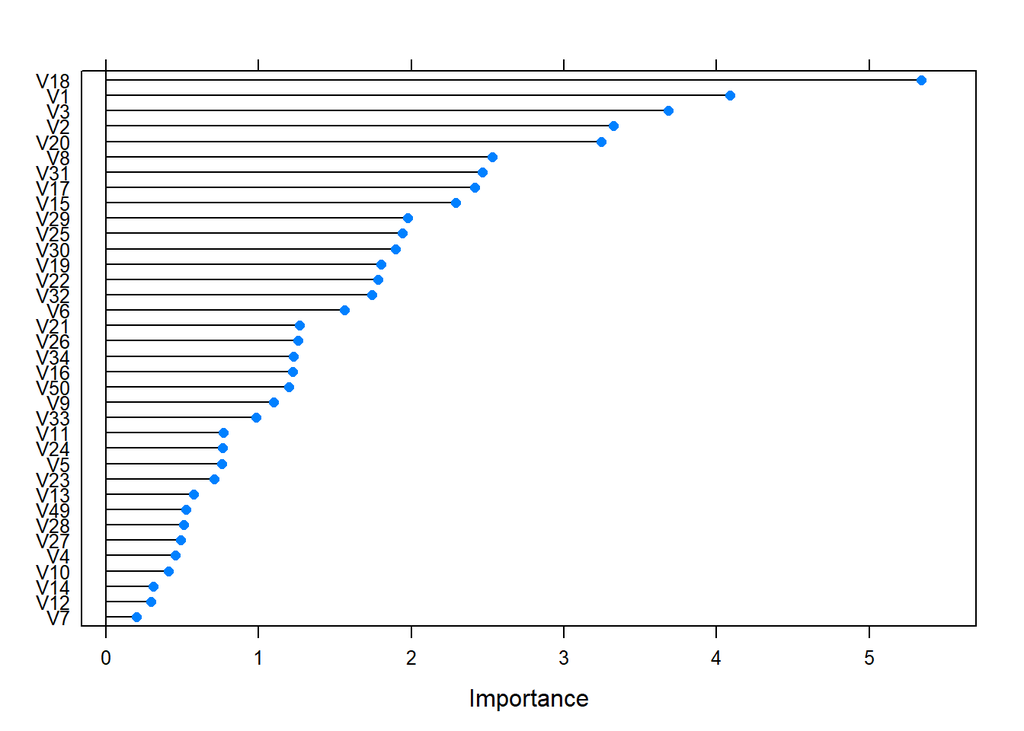

```r
fitControl <- trainControl(## 10-fold CV
  method = "cv",
  number = 10,
  savePredictions = TRUE
)

## Logistic Regression MODEL
logistic_fit<-train(V59 ~.,data=train.df,method="glm",
                     preProcess = c("center", "scale"),
                    family=binomial(),trControl=fitControl,
                    tuneLength=20)



importance <- varImp(logistic_fit,scale= FALSE)
plot(importance)
```

```r
test_pred <- predict(logistic_fit, newdata = test.df)

table(test_pred,test.df$V59)

#test_pred   0   1
#        0 282  21
#        1  13  36
```

```r
#confusion matrix

confusionMatrix(test_pred, test.df$V59 , positive = '1', mode = "everything")
```

```
## Confusion Matrix and Statistics
##
##           Reference
## Prediction   0   1
##          0 282  21
##          1  13  36
##
##                Accuracy : 0.9034
##                  95% CI : (0.8676, 0.9322)
##     No Information Rate : 0.8381
##     P-Value [Acc > NIR] : 0.0002803
##
##                   Kappa : 0.6228
##
##  Mcnemar's Test P-Value : 0.2299491
##
##             Sensitivity : 0.6316
##             Specificity : 0.9559
##          Pos Pred Value : 0.7347
##          Neg Pred Value : 0.9307
##               Precision : 0.7347
##                  Recall : 0.6316
##                      F1 : 0.6792
##              Prevalence : 0.1619
##          Detection Rate : 0.1023
##    Detection Prevalence : 0.1392
##       Balanced Accuracy : 0.7938
##
##        'Positive' Class : 1
##
```

```r
mean(test_pred == test.df$V59)
```

```
## [1] 0.9034091
```

[output not shown]

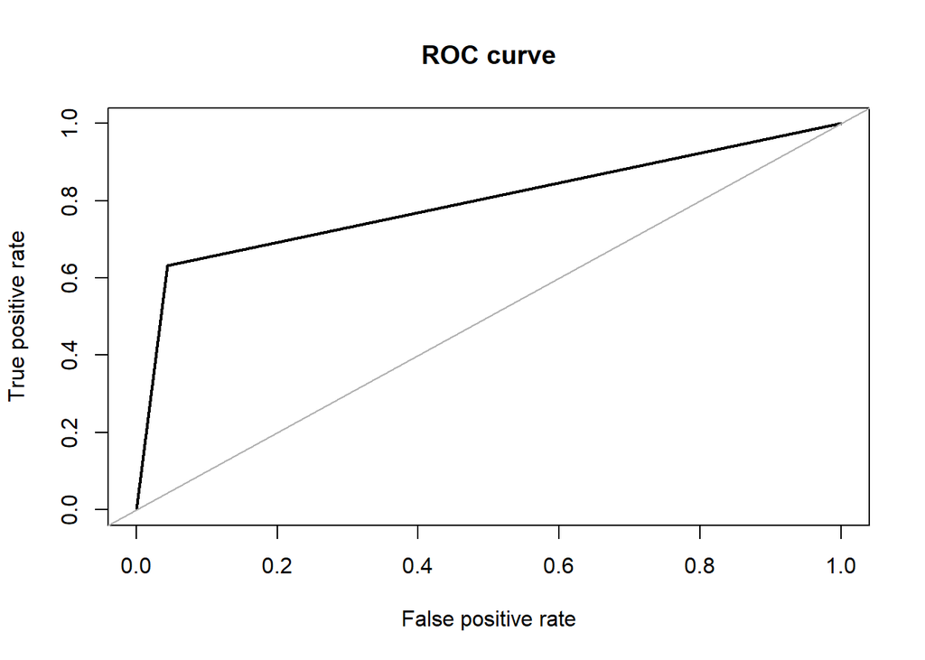

```
## Area under the curve (AUC): 0.794
```

**Results:** We test the model with the test data that was initially split out from the overall dataset

### Naive Bayes

```r
load('covid_data_new_masked')

masked <- covid_data %>%
  mutate(V59 = factor(V59, labels   = c('Normal','COVID19')))

sum(colSums(is.na(masked)))
```

```
## [1] 0
```

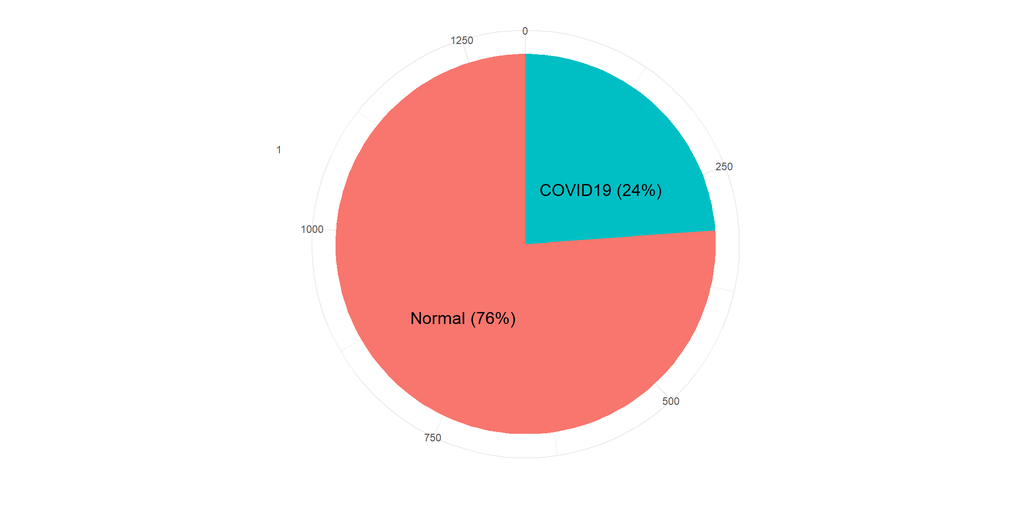

```r
resTable <- masked %>% tabyl(V59)
resTable$labels <- paste0(resTable$V59, " (", scales::percent(resTable$percent), ") ")

resTable %>%ggplot(aes(x=factor(1),y=n, fill=V59))+
  geom_bar(width = 1, stat='identity')+
  coord_polar("y")+
  theme_minimal()+
  geom_text(aes(y = c(800,200),
            label = labels), size=5)+
  theme(legend.position = 'none')+
  labs(y='', x='')
```

**Filtering near-zero variance predictors**

To filter for near-zero variance predictors, the caret package function `nearZeroVar` will return the column numbers of any predictors with 0 variance

```r
## When predictors should be removed, a vector of integers is
## returned that indicates which columns should be removed.
ZeroVar <- nearZeroVar(masked)
ZeroVar
```

```
##  [1] 35 36 37 38 39 40 41 42 43 44 45 46 47 48 51 52 53 54 55 56 57 58
```

```r
var(masked$V35)
```

```
## [1] 0
```

```r
length(ZeroVar)
```

```
## [1] 22
```

The function returns column numbers denoting the predictors that are recommended for deletion:

```r
filtered.dataset <- masked[, -ZeroVar]
```

**Feature Selection**

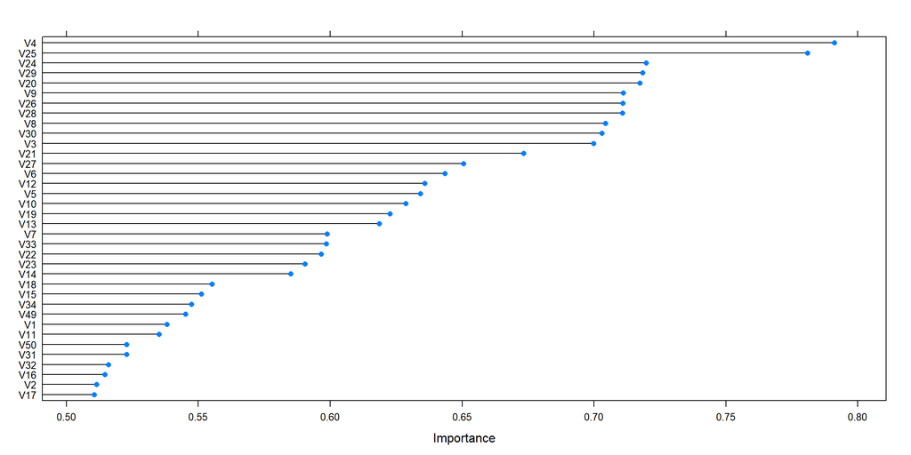

```r
set.seed(690)

# prepare training scheme
control <- trainControl(method = "cv", number = 10)
# train the model
model <- train(V59~. , data=filtered.dataset,
               method = "lvq",
               trControl = control)

# estimate variable importance
importance <- varImp(model, scale=FALSE)
# summarize importance
#print(importance)

# plot importance
plot(importance)
```

```r
significant_features <- c(predictors(rfRFE)[1:15], 'V59')
dataset_after_fs <- filtered.dataset[, significant_features]
```

**Spliting Data**

The training and test sets were created using stratified random sampling:

```r
# Create Training and Test data
set.seed(1234)
training_data <- dataset_after_fs %>%
    dplyr::select(V59) %>%
    unlist() %>%
    createDataPartition(p = 0.75, list = FALSE)
X_train <- dataset_after_fs %>%
    dplyr::select(-V59) %>%
    slice(training_data) %>%
    data.frame()
Y_train <- dataset_after_fs %>%
    dplyr::select(V59) %>%
    slice(training_data) %>%
    unlist()
X_test <- dataset_after_fs %>%
    dplyr::select(-V59) %>%
    slice(-training_data) %>%
    data.frame()
Y_test <- dataset_after_fs %>%
    dplyr::select(V59) %>%
    slice(-training_data) %>%
    unlist()
```

downSample and upSample functions from the caret package, that readjust the class frequencies. Each takes arguments for the predictors (called x) and the outcome class (y). Both functions return a data frame with the sampled version of the training set:

**Naive bayes on data_masking**

Naive Bayes is a classification technique based on Bayes’ theorem with an assumption of independence between predictors. In simple terms, a Naive Bayes classifier assumes that the presence of a particular feature in a class is unrelated to the presence of any other feature.

```r
train_control <- trainControl(method = "cv", number = 10,
                    search = 'random',
                   summaryFunction = twoClassSummary,classProbs = TRUE)
#Naive algorithm
set.seed(1234)
nb_fit <- train(X_train, Y_train,
                    method = "nb",
                    metric = "ROC",
                    preProcess=c("scale","center"),
                    trControl= train_control)
nb_fit_full <- train(V59~.,masked,
                    method = "nb",
                    metric = "ROC",
                    preProcess=c("scale","center"),
                    trControl= train_control)

# results
table(predict(nb_fit, X_train), Y_train)
```

```
##          Y_train
##           Normal COVID19
##   Normal     699      96
##   COVID19     51     139
```

```r
confusionMatrix(nb_fit)
```

```
## Cross-Validated (10 fold) Confusion Matrix
##
## (entries are percentual average cell counts across resamples)
##
##           Reference
## Prediction Normal COVID19
##    Normal    70.8    10.1
##    COVID19    5.4    13.8
##
##  Accuracy (average) : 0.8457
```

```r
confusionMatrix(nb_fit_full)
```

```
## Cross-Validated (10 fold) Confusion Matrix
##
## (entries are percentual average cell counts across resamples)
##
##           Reference
## Prediction Normal COVID19
##    Normal    72.7    12.9
##    COVID19    3.4    10.9
##
##  Accuracy (average) : 0.8363
```

```r
#Predicting the test set results
nb.pred <- predict(nb_fit, X_test)

accuracy.meas(response = Y_test, predicted = nb.pred)
```

```
##
## Call:
## accuracy.meas(response = Y_test, predicted = nb.pred)
##
## Examples are labelled as positive when predicted is greater than 0.5
##
## precision: 0.238
## recall: 1.000
## F: 0.192
```

```r
confusionMatrix(nb.pred, Y_test, positive = 'COVID19')
```

```
## Confusion Matrix and Statistics
##
##           Reference
## Prediction Normal COVID19
##    Normal     235      38
##    COVID19     15      40
##
##                Accuracy : 0.8384
##                  95% CI : (0.794, 0.8766)
##     No Information Rate : 0.7622
##     P-Value [Acc > NIR] : 0.0004808
##
##                   Kappa : 0.5039
##
##  Mcnemar's Test P-Value : 0.0025117
##
##             Sensitivity : 0.5128
##             Specificity : 0.9400
##          Pos Pred Value : 0.7273
##          Neg Pred Value : 0.8608
##              Prevalence : 0.2378
##          Detection Rate : 0.1220
##    Detection Prevalence : 0.1677
##       Balanced Accuracy : 0.7264
##
##        'Positive' Class : COVID19
##
```

The ROC and lift curves are created from these objects. For example:

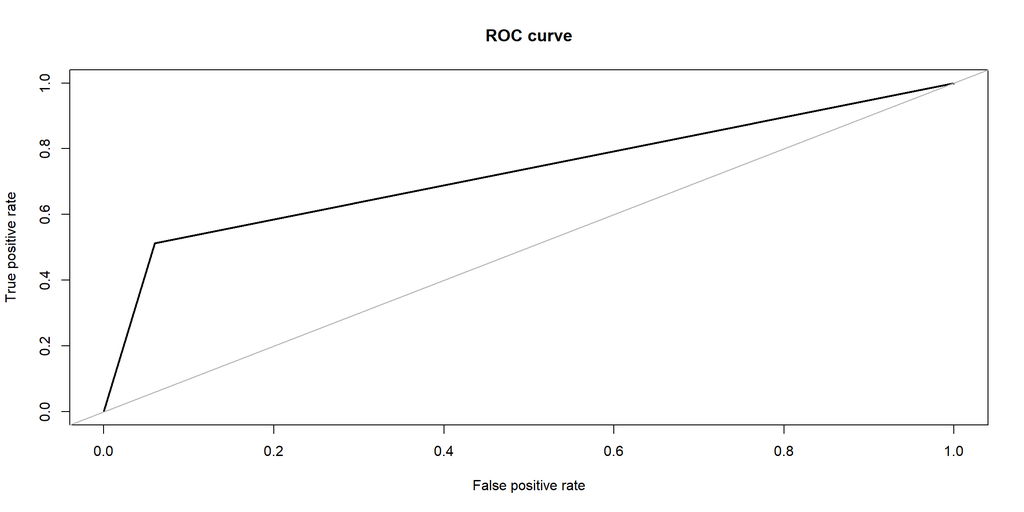

```
## Area under the curve (AUC): 0.726
```

```r
roc.curve(Y_test, nb.pred, plotit = T)
```

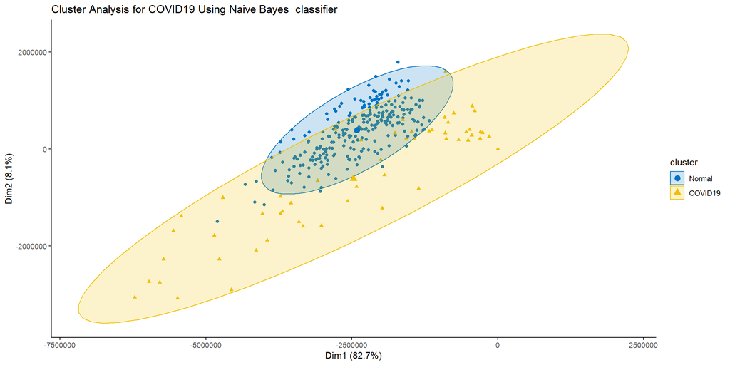

```r
# Visualize Naive Bayes clustering

fviz_cluster(list(data=X_test, cluster=nb.pred),
             ellipse.type = 'norm',geom = 'point',
             stand = F, palette='jco',
             main='Cluster Analysis for COVID19 Using Naive Bayes  classifier',
             ggtheme = theme_classic())
```

## Explanations

Apart from prediction of positive and negative for COVID-19 cases from CXR images, we try providing an explanation of which areas of the image contributes towards the predicted results. Local interpretable model-agnostic explanations (LIME) [17] is a local surrogate model. That is instead of explaining the global prediction, it only explains the local prediction. Therefore once the predictions are available, the LIME model can be run, in hope that, the model finds the areas of the image that contributes most towards the prediction.

Given any(black box/transparent) model, the Lime model probes the model and gets the output any number of time(theoritically). Lime creates a data set consist of permutated samples of the images, and feed those images to the model and tries to predict what happens to the predictions for the permutated samples.

We initially ran our application, while feeding the whole image. However, as expected the areas where the lime model is trying to explain, is outside the intended region. For that reason, we give the model, the masked lungs image as input, while the other parts of the image is black. We thus, force the lime model to do any changes in the model on the intended area. This time, as expected the lime model focuses more on the parts of the lungs and thus gives a better performance.

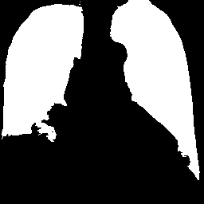

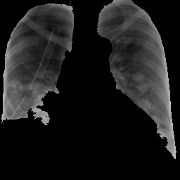

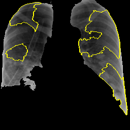

**Parameters and settings:** As a part of preprocessing of the images to be fed to the lime model, we do greyscaling of the image. While no resizing is done, the image is processed so that the 1 channel greyscaled masked image is fed to the LIME model.

Number of features to find is set to 10.

Only “positive” areas are marked in the explanation image.

## Benchmark Evaluation

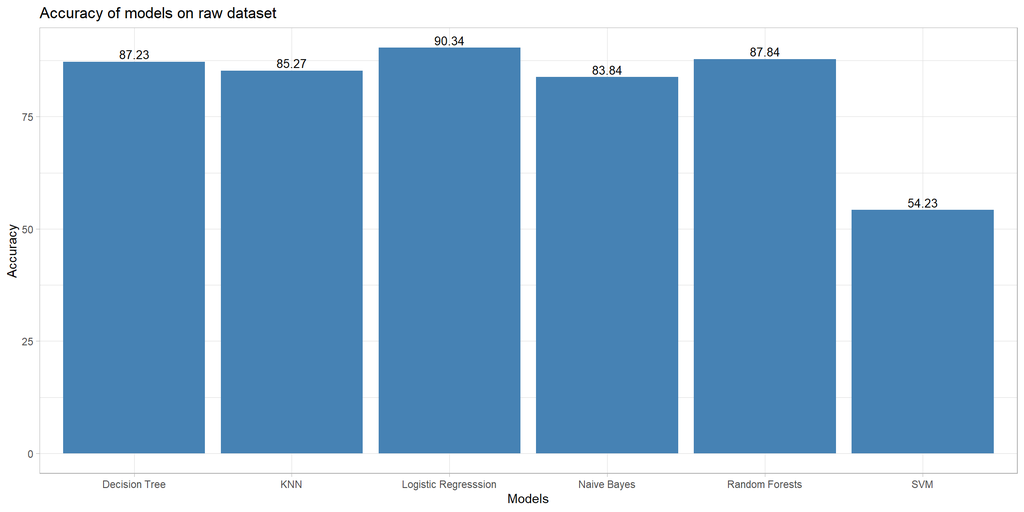

In accordance to [18], where in the author presented a network for detection of COVID-19 cases using Deep Neural Networks with X-Ray images.The paper presents a detailed comparison study of their network with respect to other models for COVID-19 detection, in terms of accuracy. The details of the data-set used is explained in the following paragraph.

The database was developed by [7] using images from various sources. The database is constantly upgraded, as of now, the database content comprise of around “201” COVID-19 positive X-Ray images.There were no images, which represent X-Ray of normal lungs, hence we have used thousand healthy X-Ray images from our original database as negative class, which we have used to feed our original models.

In the following sections, we present the figures that are obtained by training the models with the same data-set that [18] used in his experiment followed by the comparison table :

#### Comparison of different models

[output not shown]

### Random Forest

```r
# Confusion Matrix and Statistics
#
#           Reference
# Prediction   0   1
#          0 245  18
#          1   7  31
#
#               Accuracy : 0.9169
#                  95% CI : (0.8798, 0.9455)
#     No Information Rate : 0.8372
#     P-Value [Acc > NIR] : 3.802e-05
#
#                   Kappa : 0.665
#
#  Mcnemar's Test P-Value : 0.0455
#
#             Sensitivity : 0.6327
#             Specificity : 0.9722
#          Pos Pred Value : 0.8158
#          Neg Pred Value : 0.9316
#               Precision : 0.8158
#                  Recall : 0.6327
#                      F1 : 0.7126
#              Prevalence : 0.1628
#          Detection Rate : 0.1030
#    Detection Prevalence : 0.1262
#       Balanced Accuracy : 0.8024
#
#        'Positive' Class : 1
```

### kNN

```r
# Confusion Matrix and Statistics
#
#           Reference
# Prediction   0   1
#          0 283  21
#          1  12  36
#
#                Accuracy : 0.9062
#                  95% CI : (0.8709, 0.9346)
#     No Information Rate : 0.8381
#     P-Value [Acc > NIR] : 0.0001493
#
#                   Kappa : 0.6311
#
#  Mcnemar's Test P-Value : 0.1637344
#
#             Sensitivity : 0.9593
#             Specificity : 0.6316
#          Pos Pred Value : 0.9309
#          Neg Pred Value : 0.7500
#              Prevalence : 0.8381
#          Detection Rate : 0.8040
#    Detection Prevalence : 0.8636
#       Balanced Accuracy : 0.7955
#
#        'Positive' Class : 0
```

### Logistic Regression

```r
# Confusion Matrix and Statistics
#
#           Reference
# Prediction   0   1
#          0 282  21
#          1  13  36
#
#                Accuracy : 0.9034
#                  95% CI : (0.8676, 0.9322)
#     No Information Rate : 0.8381
#     P-Value [Acc > NIR] : 0.0002803
#
#                   Kappa : 0.6228
#
#  Mcnemar's Test P-Value : 0.2299491
#
#             Sensitivity : 0.9559
#             Specificity : 0.6316
#          Pos Pred Value : 0.9307
#          Neg Pred Value : 0.7347
#              Prevalence : 0.8381
#          Detection Rate : 0.8011
#    Detection Prevalence : 0.8608
#       Balanced Accuracy : 0.7938
#
#        'Positive' Class : 0
```

### Decision Tree

```r
# Confusion Matrix and Statistics
#
#           Reference
# Prediction   0   1
#          0 243  21
#          1   9  28
#
#                Accuracy : 0.9003
#                  95% CI : (0.8608, 0.9317)
#     No Information Rate : 0.8372
#     P-Value [Acc > NIR] : 0.001154
#
#                   Kappa : 0.5943
#
#  Mcnemar's Test P-Value : 0.044610
#
#             Sensitivity : 0.57143
#             Specificity : 0.96429
#          Pos Pred Value : 0.75676
#          Neg Pred Value : 0.92045
#               Precision : 0.75676
#                  Recall : 0.57143
#                      F1 : 0.65116
#              Prevalence : 0.16279
#          Detection Rate : 0.09302
#    Detection Prevalence : 0.12292
#       Balanced Accuracy : 0.76786
#
#        'Positive' Class : 1
```

### Naive Bayes

```r
## Confusion Matrix and Statistics
##
##           Reference
## Prediction Normal COVID19
##    Normal     235      24
##    COVID19     15      26
##
##                Accuracy : 0.87
##                  95% CI : (0.8266, 0.9059)
##     No Information Rate : 0.8333
##     P-Value [Acc > NIR] : 0.04857
##
##                   Kappa : 0.4957
##
##  Mcnemar's Test P-Value : 0.20018
##
##             Sensitivity : 0.52000
##             Specificity : 0.94000
##          Pos Pred Value : 0.63415
##          Neg Pred Value : 0.90734
##              Prevalence : 0.16667
##          Detection Rate : 0.08667
##    Detection Prevalence : 0.13667
##       Balanced Accuracy : 0.73000
##
##        'Positive' Class : COVID19
##
```

### Support Vector Machine

```r
#
# Confusion Matrix and Statistics
#
#           Reference
# Prediction   0   1
#          0  26   0
#          1 307 346
#
#                Accuracy : 0.5479
#                  95% CI : (0.5096, 0.5858)
#     No Information Rate : 0.5096
#     P-Value [Acc > NIR] : 0.02506
#
#                   Kappa : 0.0795
#
#  Mcnemar's Test P-Value : < 2e-16
#
#             Sensitivity : 1.00000
#             Specificity : 0.07808
#          Pos Pred Value : 0.52986
#          Neg Pred Value : 1.00000
#              Prevalence : 0.50957
#          Detection Rate : 0.50957
#    Detection Prevalence : 0.96171
#       Balanced Accuracy : 0.53904
#
#        'Positive' Class : 1
```

## Final Analysis

Based on our approach, we initially tried to extract the features out of the CXR images without any segmentation. However, we found that the area of interest i.e., the lung area is a very small segment of the whole image. Hence, the noise around the lung area dominates the outcome of the classification. Moreover, we found that quality of CXR images highly affects the feature vectors. For this reason, we segmented the images to find the area of interest and extract our features on corresponding lung-segment. The results were better in that case. However, we could not deal with quality of images in terms of light exposure.

We tried explaining our prediction using `LIME` image module. Intially, we tried applying LIME on the whole image. However, the results were not good. All the areas highlighted by LIME were outside of lung-portion. So, we tried applying LIME on segmented image by applying black background on the non-lung area hoping that the LIME super-pixels will ignore the black backgrounded regions. We manually confirmed that any perturbed image outside the lung-segment area doesn’t get a different prediction. However, we partially succeded on this approach where we noticed that only the negative COVID images (False Negatives too) were correctly marked by LIME. However, positive images could not be properly annotated by LIME within the area of interest.

We also applied classification algorithms, on benchmark dataset and compared the performaces of simple intrinsically explainable models we used and found that some of the very simple models such as kNN, Naive Bayes and Random Forest are giving high accuracy. To our astonishment, SVM couldn’t perform well in comparsion to these simpler models.

We proposed to work on an ensemble architecture where we use our simpler models to boost our confidence in prediction. However, such an approach couldn’t give us the kind of robustness we expected. Hence, after seeing results with the ensemble approach, we dropped the idea of ensemble classification.

We found Local Binary Pattern to be a powerful texture based descriptor, where the only justification of its usefulness can be seen when we compare our results with Neural Network based approaches in the benchmark section.

## Conclusion

We applied intrinsically explainable models and LIME explainer on CXR images, for COVID detection and explaination. The results obtained by the classifiers were of higher accuracy whereas LIME failed to perform the similarly. We observed that LBP are good dicriminatory feature vectors for CXR images, however we cannot mitigate the effect of luminosity, brightness and quality to the images. These factors add bias to our classifiers.

## References

[1] World Health Organisation, Novel Coronavirus – China 2020, (2020). https://www.who.int/csr/don/12-january-2020-novel-coronavirus-china/en/.

[2] J. Zhao, Y. Zhang, X. He, P. Xie, COVID-ct-dataset: A ct scan dataset about covid-19, ArXiv. abs/2003.13865 (2020).

[3] M. Wiberg, A. Taylor, D. Rosner, Responding to the covid-19 pandemic: An invitation, Interactions. 27 (2020) 5. https://doi.org/10.1145/3392538.

[4] L. Wang, A. Wong, COVID-net: A tailored deep convolutional neural network design for detection of covid-19 cases from chest x-ray images, arXiv Preprint arXiv:2003.09871. (2020).

[5] A. Narin, C. Kaya, Z. Pamuk, Automatic detection of coronavirus disease (covid-19) using x-ray images and deep convolutional neural networks, arXiv Preprint arXiv:2003.10849. (2020).

[6] M. Karim, T. Döhmen, D. Rebholz-Schuhmann, S. Decker, M. Cochez, O. Beyan, others, Deepcovidexplainer: Explainable covid-19 predictions based on chest x-ray images, arXiv Preprint arXiv:2004.04582. (2020).

[7] J.P. Cohen, P. Morrison, L. Dao, COVID-19 image data collection, arXiv 2003.11597. (2020). https://github.com/ieee8023/covid-chestxray-dataset.

[8] S. Wang, B. Kang, J. Ma, X. Zeng, M. Xiao, J. Guo, M. Cai, J. Yang, Y. Li, X. Meng, others, A deep learning algorithm using ct images to screen for corona virus disease (covid-19), MedRxiv. (2020).

[9] L. Li, L. Qin, Z. Xu, Y. Yin, X. Wang, B. Kong, J. Bai, Y. Lu, Z. Fang, Q. Song, others, Artificial intelligence distinguishes covid-19 from community acquired pneumonia on chest ct, Radiology. (2020) 200905.

[10] D. Singh, V. Kumar, M. Kaur, Classification of covid-19 patients from chest ct images using multi-objective differential evolution–based convolutional neural networks, European Journal of Clinical Microbiology & Infectious Diseases. (2020) 1–11.

[11] D.S. Kermany, M. Goldbaum, W. Cai, C.C.S. Valentim, H. Liang, S.L. Baxter, A. McKeown, G. Yang, X. Wu, F. Yan, J. Dong, M.K. Prasadha, J. Pei, M.Y.L. Ting, J. Zhu, C. Li, S. Hewett, J. Dong, I. Ziyar, A. Shi, R. Zhang, L. Zheng, R. Hou, W. Shi, X. Fu, Y. Duan, V.A.N. Huu, C. Wen, E.D. Zhang, C.L. Zhang, O. Li, X. Wang, M.A. Singer, X. Sun, J. Xu, A. Tafreshi, M.A. Lewis, H. Xia, K. Zhang, Identifying medical diagnoses and treatable diseases by image-based deep learning, Cell. 172 (2018) 1122–1131.e9. https://doi.org/https://doi.org/10.1016/j.cell.2018.02.010.

[12] T. Ojala, M. Pietikäinen, D. Harwood, A comparative study of texture measures with classification based on featured distributions, Pattern Recognition. 29 (1996) 51–59.

[13] P.L. Paula Filho, L.S. Oliveira, S. Nisgoski, A.S. Britto, Forest species recognition using macroscopic images, Machine Vision and Applications. 25 (2014) 1019–1031.

[14] O. Ronneberger, P. Fischer, T. Brox, U-net: Convolutional networks for biomedical image segmentation, in: N. Navab, J. Hornegger, W.M. Wells, A.F. Frangi (Eds.), Medical Image Computing and Computer-Assisted Intervention – Miccai 2015, Springer International Publishing, Cham, 2015: pp. 234–241.

[15] R.M. Pereira, D. Bertolini, L.O. Teixeira, C.N. Silla Jr, Y.M. Costa, COVID-19 identification in chest x-ray images on flat and hierarchical classification scenarios, Computer Methods and Programs in Biomedicine. (2020) 105532.

[16] L. Sørensen, S.B. Shaker, M. De Bruijne, Texture classification in lung ct using local binary patterns, in: International Conference on Medical Image Computing and Computer-Assisted Intervention, Springer, 2008: pp. 934–941.

[17] M.T. Ribeiro, S. Singh, C. Guestrin, " Why should i trust you?" Explaining the predictions of any classifier, in: Proceedings of the 22nd Acm Sigkdd International Conference on Knowledge Discovery and Data Mining, 2016: pp. 1135–1144.

[18] T. Ozturk, M. Talo, E.A. Yildirim, U.B. Baloglu, O. Yildirim, U.R. Acharya, Automated detection of covid-19 cases using deep neural networks with x-ray images, Computers in Biology and Medicine. (2020) 103792.

[^1]: https://github.com/rezacsedu/DeepCOVIDExplainer
[^2]: https://www.kaggle.com/paultimothymooney/chest-xray-pneumonia
[^3]: https://www.kaggle.com/c/rsna-pneumonia-detection-challenge
[^4]: https://github.com/ieee8023/covid-chestxray-dataset
[^5]: https://github.com/rezacsedu/DeepCOVIDExplainer
[^6]: https://www.kaggle.com/paultimothymooney/chest-xray-pneumonia
[^7]: https://www.kaggle.com/c/rsna-pneumonia-detection-challenge
[^8]: https://github.com/ieee8023/covid-chestxray-dataset